# sandbox-01

Joshua Rosenberg

12/27/2017

# Sandbox - 03

### Background

This is a sandbox for exploring the data, in preparation for adding to the results section.

This document is organized around two sets of model specifications:

1. Fit using the R package `mclust`
2. Fit using the commerical software `MPlus`

Both are interfaced to through the `tidyLPA` package.

### Models that are specified

**mclust**

For models fit using `mclust`, eight model specifications are tested, where all five refers to the variables for cognitive (learning), behavioral (hard working), and affective (enjoy), and challenge and competence, where three refers to just the three engagement measures. Note that the prior is to regularize the parameter estimates to be more less likely to be extreme (and therefore to be less likely to lead to convergence problems, but possibly less meaningful / interpretable).

- All five variables w/ no prior
- All five w/ prior
- All five w/ no prior and standardized (M = 0, SD = 1) variables
- All five w/ prior and standardized (M = 0, SD = 1) variables
- Three variables w/ no prior
- Three w/ prior
- Three w/ no prior and standardized (M = 0, SD = 1) variables
- Three w/ prior and standardized (M = 0, SD = 1) variables

*MPlus*

- All five variables
- All five and standardized (M = 0, SD = 1) variables
- Three variables prior
- Three and standardized (M = 0, SD = 1) variables

# 1. mclust profiles

### 1A. All five - no prior

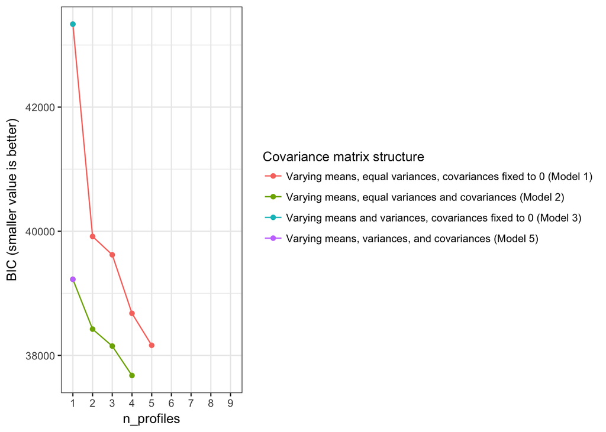

### 1B. All five - prior

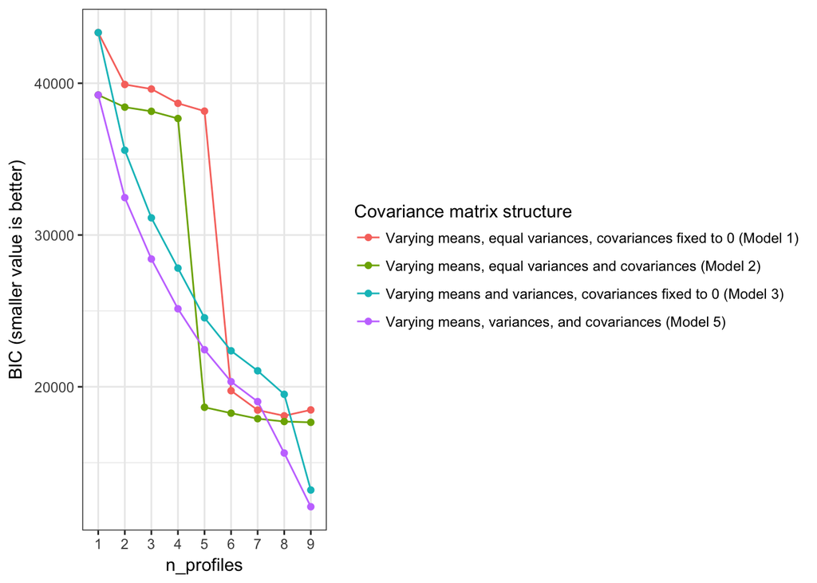

### 1C. All five - no prior - standardized

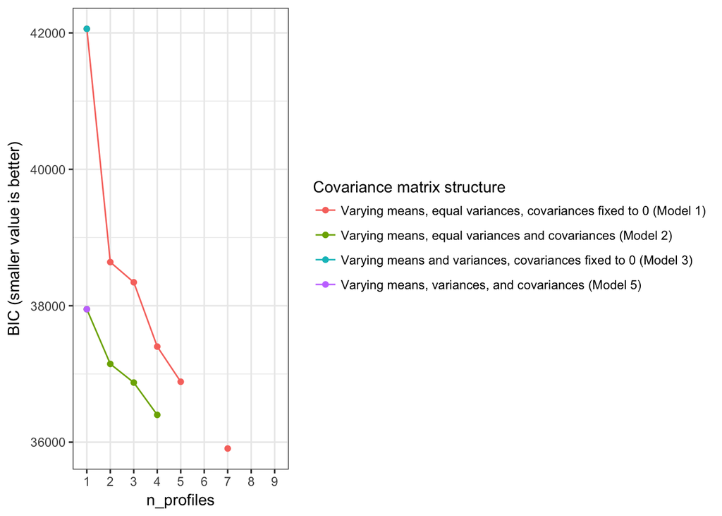

### 1D. All five - prior - standardized

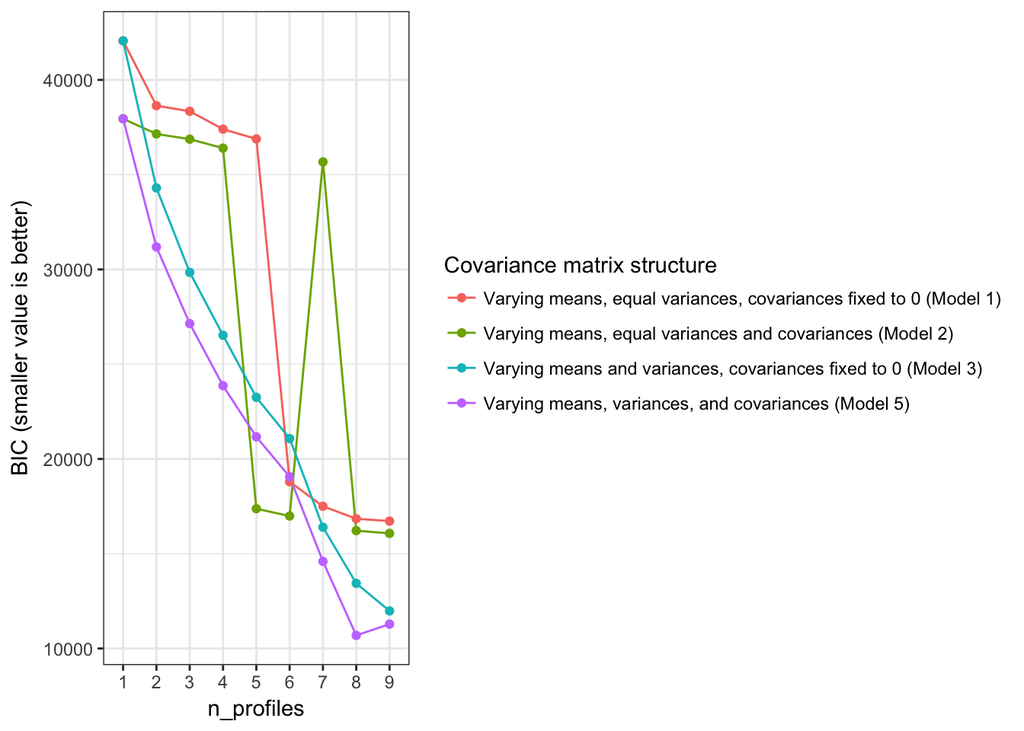

### 1E. Three - no prior

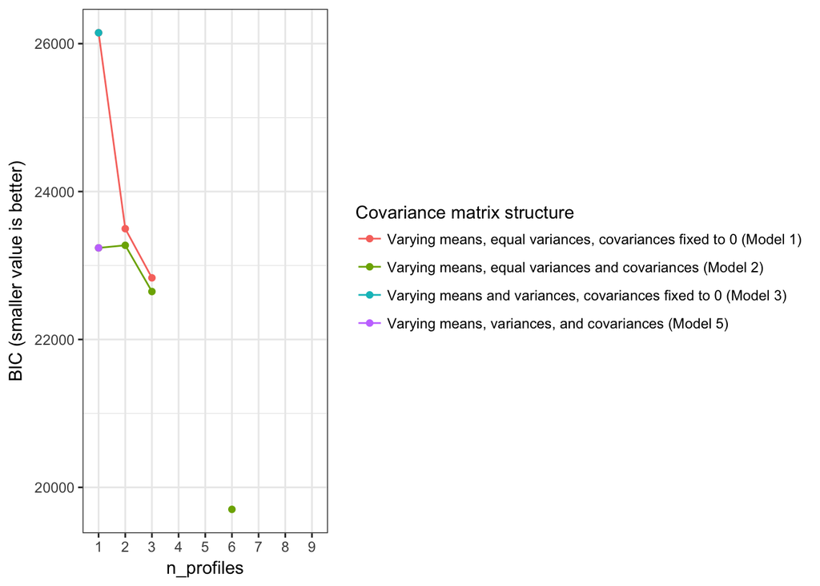

### 1F. Three - prior

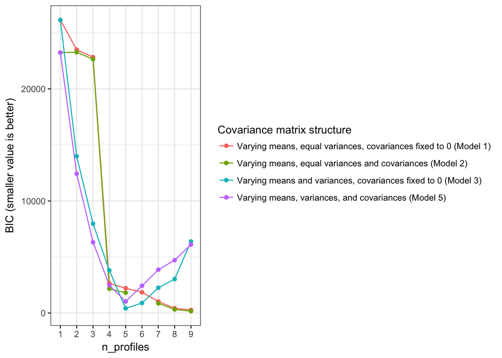

### 1G. Three - no prior - standardized

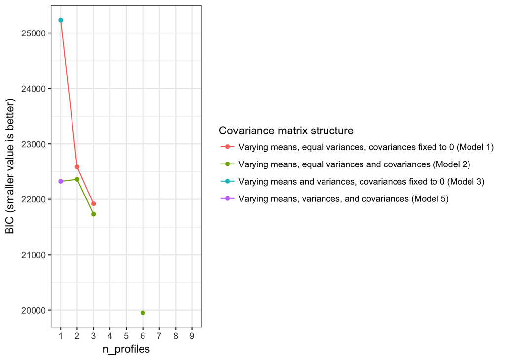

### 1H. Three - prior - standardized

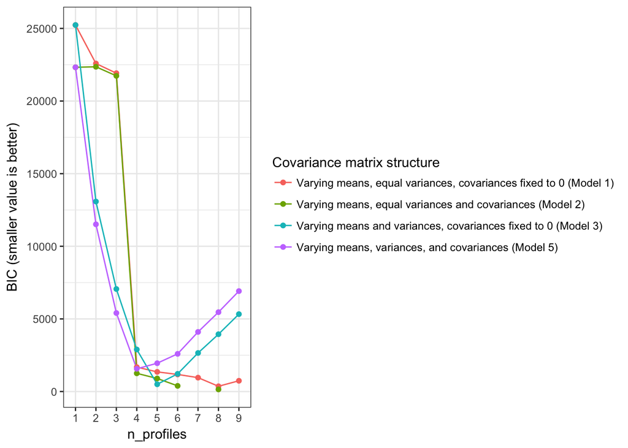

# Mplus

### 2A: All five variables w/ no prior

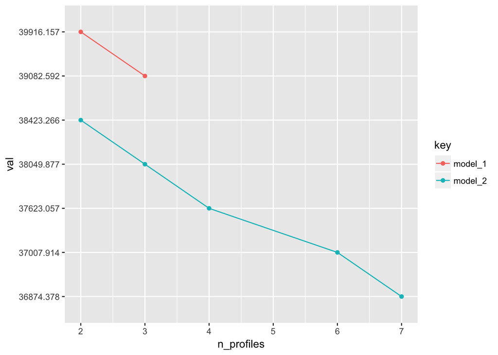

### 2B: All five w/ no prior and standardized (M = 0, SD = 1) variables

```
##   n_profiles             model_1             model_2             model_3
## 1          2           38639.754           37146.863 Convergence problem
## 2          3           37806.188           36773.473 Convergence problem
## 3          4 Convergence problem           36465.555 Convergence problem
## 4          5 Convergence problem   LL not replicated Convergence problem
## 5          6 Convergence problem           35800.052 Convergence problem
## 6          7 Convergence problem           35597.975 Convergence problem
## 7          8 Convergence problem Convergence problem Convergence problem
## 8          9 Convergence problem Convergence problem Convergence problem
## 9         10 Convergence problem Convergence problem Convergence problem
##               model_4             model_5             model_6
## 1 Convergence problem Convergence problem Convergence problem
## 2 Convergence problem Convergence problem Convergence problem
## 3 Convergence problem Convergence problem Convergence problem
## 4 Convergence problem Convergence problem Convergence problem
## 5 Convergence problem Convergence problem Convergence problem
## 6 Convergence problem Convergence problem Convergence problem
## 7 Convergence problem Convergence problem Convergence problem
## 8 Convergence problem Convergence problem Convergence problem
## 9 Convergence problem Convergence problem Convergence problem
```

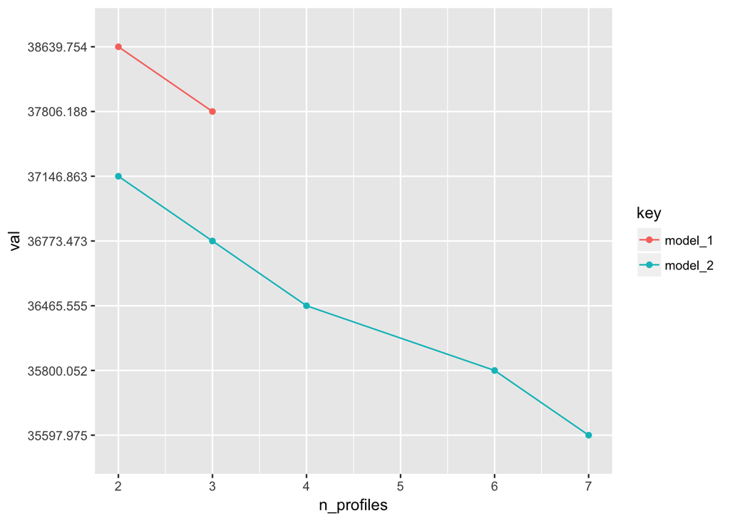

### 2C: Three variables w/ no prior

```
##   n_profiles             model_1             model_2             model_3
## 1          2           23497.708           22585.734 Convergence problem
## 2          3           22720.718           22111.718 Convergence problem
## 3          4 Convergence problem           21747.949 Convergence problem
## 4          5 Convergence problem           21570.225 Convergence problem
## 5          6 Convergence problem   LL not replicated Convergence problem
## 6          7 Convergence problem   LL not replicated Convergence problem
## 7          8 Convergence problem Convergence problem Convergence problem
## 8          9 Convergence problem Convergence problem Convergence problem
## 9         10 Convergence problem Convergence problem Convergence problem
##               model_4             model_5             model_6
## 1 Convergence problem Convergence problem Convergence problem
## 2 Convergence problem Convergence problem Convergence problem
## 3 Convergence problem Convergence problem Convergence problem
## 4 Convergence problem Convergence problem Convergence problem
## 5 Convergence problem Convergence problem Convergence problem
## 6 Convergence problem Convergence problem Convergence problem
## 7 Convergence problem Convergence problem Convergence problem
## 8 Convergence problem Convergence problem Convergence problem
## 9 Convergence problem Convergence problem Convergence problem
```

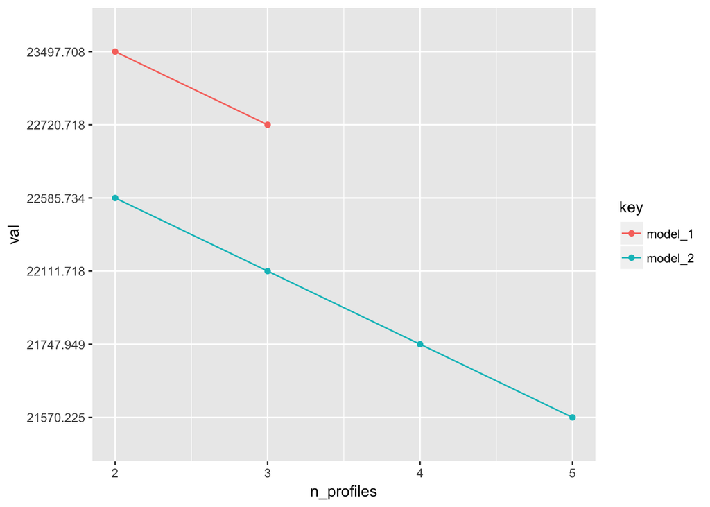

### 2D: Three w/ no prior and standardized (M = 0, SD = 1) variables

```
##   n_profiles             model_1             model_2             model_3
## 1          2           22583.219           21671.245 Convergence problem
## 2          3           21806.228   LL not replicated Convergence problem
## 3          4 Convergence problem            20833.46 Convergence problem
## 4          5 Convergence problem           20655.735 Convergence problem
## 5          6 Convergence problem   LL not replicated Convergence problem
## 6          7 Convergence problem   LL not replicated Convergence problem
## 7          8 Convergence problem Convergence problem Convergence problem
## 8          9 Convergence problem Convergence problem Convergence problem
## 9         10 Convergence problem Convergence problem Convergence problem
##               model_4             model_5             model_6
## 1 Convergence problem Convergence problem Convergence problem
## 2 Convergence problem Convergence problem Convergence problem
## 3 Convergence problem Convergence problem Convergence problem
## 4 Convergence problem Convergence problem Convergence problem
## 5 Convergence problem Convergence problem Convergence problem
## 6 Convergence problem Convergence problem Convergence problem
## 7 Convergence problem Convergence problem Convergence problem
## 8 Convergence problem Convergence problem Convergence problem
## 9 Convergence problem Convergence problem Convergence problem
```

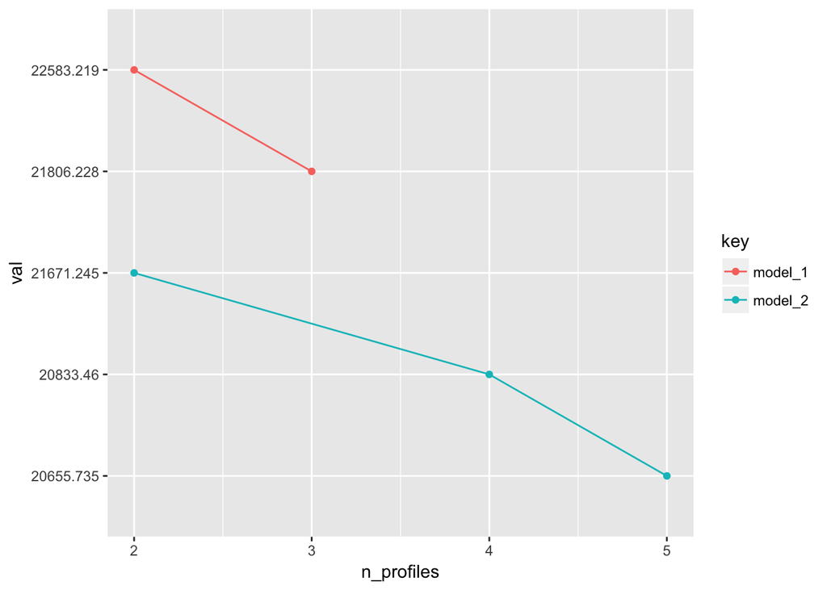